# Untitled

- datetime - hourly date + timestamp
- season - 1 = spring, 2 = summer, 3 = fall, 4 = winter
- holiday - whether the day is considered a holiday
- workingday - whether the day is neither a weekend nor holiday
- weather
- 1: Clear, Few clouds, Partly cloudy, Partly cloudy
- 2: Mist + Cloudy, Mist + Broken clouds, Mist + Few clouds, Mist
- 3: Light Snow, Light Rain + Thunderstorm + Scattered clouds, Light Rain + Scattered clouds
- 4: Heavy Rain + Ice Pallets + Thunderstorm + Mist, Snow + Fog
- temp - temperature in Celsius
- atemp - “feels like” temperature in Celsius
- humidity - relative humidity
- windspeed - wind speed
- casual - number of non-registered user rentals initiated
- registered - number of registered user rentals initiated
- count - number of total rentals

```r
train <- read_csv("C:/Users/sangdon/Desktop/kaggle-study/data/bike sharing/train.csv")
test <- read_csv("C:/Users/sangdon/Desktop/kaggle-study/data/bike sharing/test.csv")
head(train)
```

```
## # A tibble: 6 x 12
##   datetime            season holiday workingday weather  temp atemp humidity
##   <dttm>               <dbl>   <dbl>      <dbl>   <dbl> <dbl> <dbl>    <dbl>
## 1 2011-01-01 00:00:00      1       0          0       1  9.84  14.4       81
## 2 2011-01-01 01:00:00      1       0          0       1  9.02  13.6       80
## 3 2011-01-01 02:00:00      1       0          0       1  9.02  13.6       80
## 4 2011-01-01 03:00:00      1       0          0       1  9.84  14.4       75
## 5 2011-01-01 04:00:00      1       0          0       1  9.84  14.4       75
## 6 2011-01-01 05:00:00      1       0          0       2  9.84  12.9       75
## # ... with 4 more variables: windspeed <dbl>, casual <dbl>, registered <dbl>,
## #   count <dbl>
```

```r
names(train)
```

```
##  [1] "datetime"   "season"     "holiday"    "workingday" "weather"
##  [6] "temp"       "atemp"      "humidity"   "windspeed"  "casual"
## [11] "registered" "count"
```

```r
names(test)
```

```
## [1] "datetime"   "season"     "holiday"    "workingday" "weather"
## [6] "temp"       "atemp"      "humidity"   "windspeed"
```

```r
train %>%
    select(-c(casual, registered)) -> train
```

```r
all_data <- bind_rows(train, test)

glimpse(all_data)
```

```
## Rows: 17,379
## Columns: 10
## $ datetime   <dttm> 2011-01-01 00:00:00, 2011-01-01 01:00:00, 2011-01-01 02:00~
## $ season     <dbl> 1, 1, 1, 1, 1, 1, 1, 1, 1, 1, 1, 1, 1, 1, 1, 1, 1, 1, 1, 1,~
## $ holiday    <dbl> 0, 0, 0, 0, 0, 0, 0, 0, 0, 0, 0, 0, 0, 0, 0, 0, 0, 0, 0, 0,~
## $ workingday <dbl> 0, 0, 0, 0, 0, 0, 0, 0, 0, 0, 0, 0, 0, 0, 0, 0, 0, 0, 0, 0,~
## $ weather    <dbl> 1, 1, 1, 1, 1, 2, 1, 1, 1, 1, 1, 1, 1, 2, 2, 2, 2, 2, 3, 3,~
## $ temp       <dbl> 9.84, 9.02, 9.02, 9.84, 9.84, 9.84, 9.02, 8.20, 9.84, 13.12~
## $ atemp      <dbl> 14.395, 13.635, 13.635, 14.395, 14.395, 12.880, 13.635, 12.~
## $ humidity   <dbl> 81, 80, 80, 75, 75, 75, 80, 86, 75, 76, 76, 81, 77, 72, 72,~
## $ windspeed  <dbl> 0.0000, 0.0000, 0.0000, 0.0000, 0.0000, 6.0032, 0.0000, 0.0~
## $ count      <dbl> 16, 40, 32, 13, 1, 1, 2, 3, 8, 14, 36, 56, 84, 94, 106, 110~
```

```r
all_data$holiday %>% unique()
```

```
## [1] 0 1
```

```r
all_data$workingday %>% unique()
```

```
## [1] 0 1
```

```r
all_data$weather %>% unique()
```

```
## [1] 1 2 3 4
```

```r
all_data$season <- factor(all_data$season, labels = c('spring', 'summer', 'fall', 'winter'))
all_data$weather <- as.factor(all_data$weather)
all_data$workingday <- as.factor(all_data$workingday)
all_data$holiday <- as.factor(all_data$holiday)

all_data %>% mutate(year = year(datetime),
                    month = month(datetime),
                    wday = wday(datetime),
                    day = day(datetime),
                    hour = hour(datetime)) %>%
    select(year, month, wday, day, holiday, workingday, everything()) -> all_data

all_data$wday <- factor(all_data$wday, labels = c('Sun', 'Mon', 'Tue', 'Wed', 'Thur', 'Fri', 'Sat'))
all_data$month <- as.factor(all_data$month)
all_data
```

```
## # A tibble: 17,379 x 15
##     year month wday    day holiday workingday datetime            season weather
##    <int> <fct> <fct> <int> <fct>   <fct>      <dttm>              <fct>  <fct>
##  1  2011 1     Sat       1 0       0          2011-01-01 00:00:00 spring 1
##  2  2011 1     Sat       1 0       0          2011-01-01 01:00:00 spring 1
##  3  2011 1     Sat       1 0       0          2011-01-01 02:00:00 spring 1
##  4  2011 1     Sat       1 0       0          2011-01-01 03:00:00 spring 1
##  5  2011 1     Sat       1 0       0          2011-01-01 04:00:00 spring 1
##  6  2011 1     Sat       1 0       0          2011-01-01 05:00:00 spring 2
##  7  2011 1     Sat       1 0       0          2011-01-01 06:00:00 spring 1
##  8  2011 1     Sat       1 0       0          2011-01-01 07:00:00 spring 1
##  9  2011 1     Sat       1 0       0          2011-01-01 08:00:00 spring 1
## 10  2011 1     Sat       1 0       0          2011-01-01 09:00:00 spring 1
## # ... with 17,369 more rows, and 6 more variables: temp <dbl>, atemp <dbl>,
## #   humidity <dbl>, windspeed <dbl>, count <dbl>, hour <int>
```

```r
skim(all_data)
```

Data summary

| Name | all_data |
| --- | --- |
| Number of rows | 17379 |
| Number of columns | 15 |
| _______________________ |  |
| Column type frequency: |  |
| factor | 6 |
| numeric | 8 |
| POSIXct | 1 |
| ________________________ |  |
| Group variables | None |

**Variable type: factor**

| skim_variable | n_missing | complete_rate | ordered | n_unique | top_counts |
| --- | --- | --- | --- | --- | --- |
| month | 0 | 1 | FALSE | 12 | 5: 1488, 7: 1488, 12: 1483, 8: 1475 |
| wday | 0 | 1 | FALSE | 7 | Sat: 2512, Sun: 2502, Fri: 2487, Mon: 2479 |
| holiday | 0 | 1 | FALSE | 2 | 0: 16879, 1: 500 |
| workingday | 0 | 1 | FALSE | 2 | 1: 11865, 0: 5514 |
| season | 0 | 1 | FALSE | 4 | fal: 4496, sum: 4409, spr: 4242, win: 4232 |
| weather | 0 | 1 | FALSE | 4 | 1: 11413, 2: 4544, 3: 1419, 4: 3 |

**Variable type: numeric**

| skim_variable | n_missing | complete_rate | mean | sd | p0 | p25 | p50 | p75 | p100 | hist |
| --- | --- | --- | --- | --- | --- | --- | --- | --- | --- | --- |
| year | 0 | 1.00 | 2011.50 | 0.50 | 2011.00 | 2011.00 | 2012.00 | 2012.00 | 2012 | ▇▁▁▁▇ |
| day | 0 | 1.00 | 15.68 | 8.79 | 1.00 | 8.00 | 16.00 | 23.00 | 31 | ▇▇▇▇▆ |
| temp | 0 | 1.00 | 20.38 | 7.89 | 0.82 | 13.94 | 20.50 | 27.06 | 41 | ▂▇▇▇▁ |
| atemp | 0 | 1.00 | 23.79 | 8.59 | 0.00 | 16.66 | 24.24 | 31.06 | 50 | ▁▆▇▆▁ |
| humidity | 0 | 1.00 | 62.72 | 19.29 | 0.00 | 48.00 | 63.00 | 78.00 | 100 | ▁▃▇▇▆ |
| windspeed | 0 | 1.00 | 12.74 | 8.20 | 0.00 | 7.00 | 13.00 | 17.00 | 57 | ▇▆▂▁▁ |
| count | 6493 | 0.63 | 191.57 | 181.14 | 1.00 | 42.00 | 145.00 | 284.00 | 977 | ▇▃▁▁▁ |
| hour | 0 | 1.00 | 11.55 | 6.91 | 0.00 | 6.00 | 12.00 | 18.00 | 23 | ▇▇▆▇▇ |

**Variable type: POSIXct**

| skim_variable | n_missing | complete_rate | min | max | median | n_unique |
| --- | --- | --- | --- | --- | --- | --- |
| datetime | 0 | 1 | 2011-01-01 | 2012-12-31 23:00:00 | 2012-01-02 21:00:00 | 17379 |

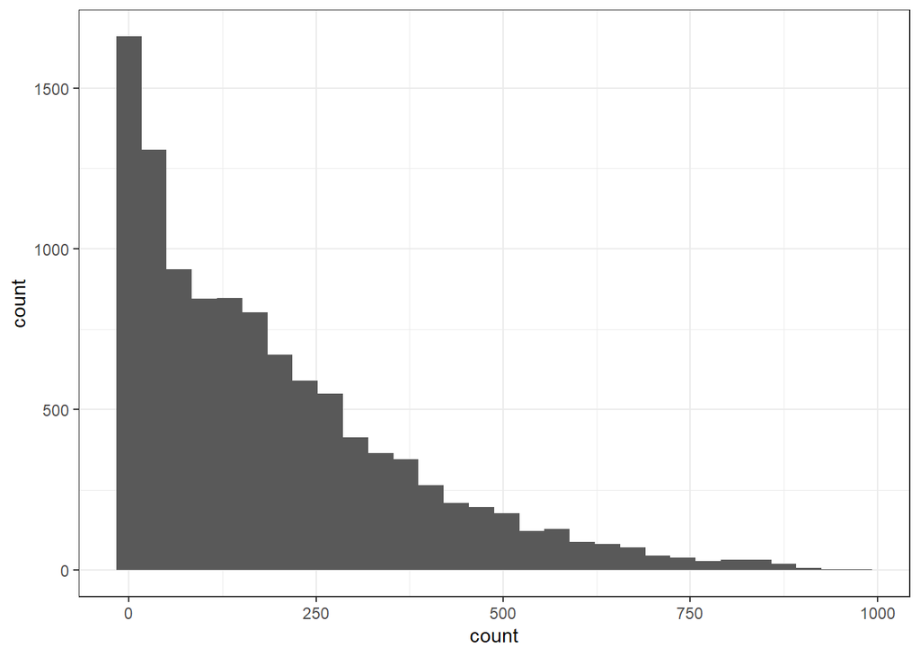

```r
all_data %>%
    ggplot(aes(x = count)) +
    geom_histogram()
```

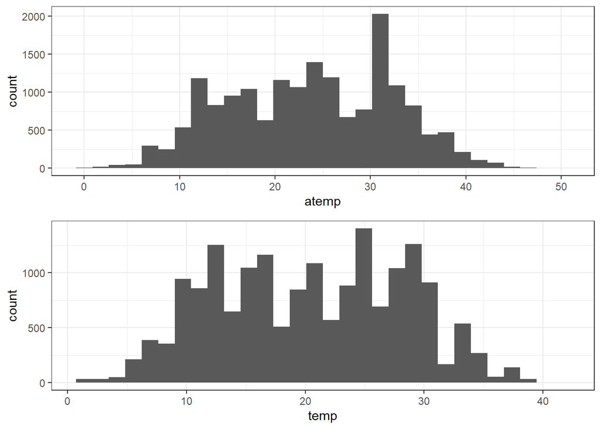

```r
p1 <- all_data %>%
    ggplot(aes(x = atemp)) +
    geom_histogram()
p2 <- all_data %>%
    ggplot(aes(x = temp)) +
    geom_histogram()

grid.arrange(grobs = list(p1, p2), col = 2)
```

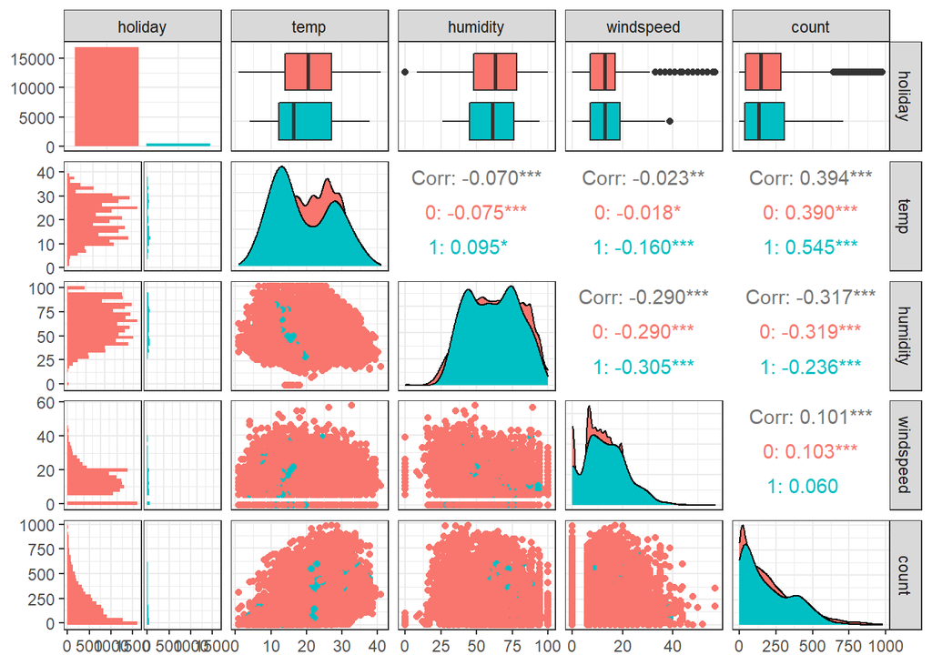

```r
all_data %>%
    select(holiday, temp, humidity, windspeed, count) %>%
    GGally::ggpairs(mapping = aes(color = holiday))
```

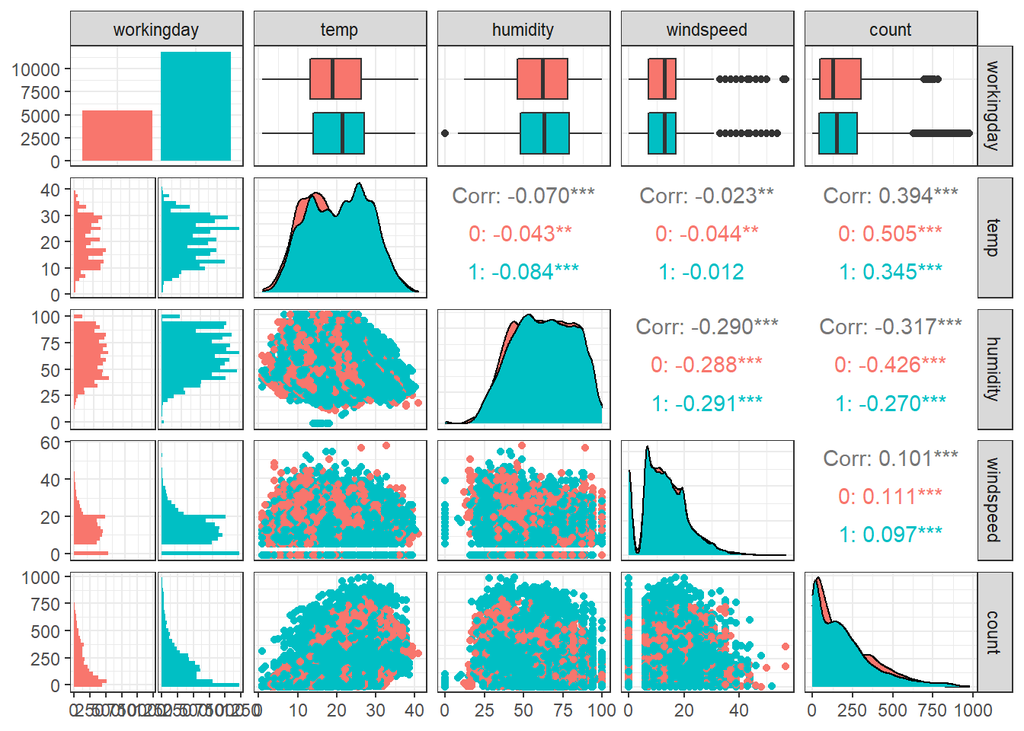

```r
all_data %>%
    select(workingday, temp, humidity, windspeed, count) %>%
    GGally::ggpairs(mapping = aes(color = workingday))
```

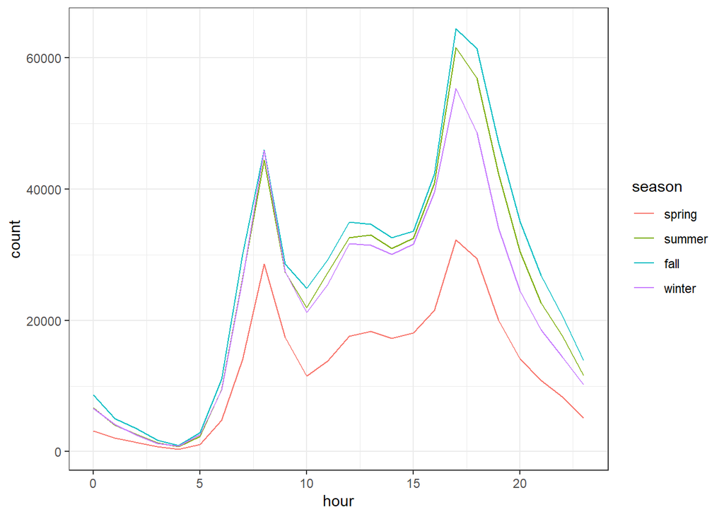

```r
all_data %>%
    group_by(season, hour) %>%
    summarise(count = sum(count, na.rm = T)) %>%
    ggplot(aes(x = hour, y = count, color = season)) +
    geom_line()
```

```r
factor_list <- sapply(all_data, is.factor) %>%
  which()

lst <- lapply(factor_list, function(i) {
  df_list <- colnames(all_data)[i]

  all_data %>%
    rename(aa = df_list) %>%
    group_by(aa, hour) %>%
    summarise(count = sum(count, na.rm = T)) %>%
    ggplot(aes(x = hour, y = count, group = aa, colour = aa)) +
    labs(title = paste0("Count by ",df_list), x = "Hour",  color = df_list) +
    theme_bw() +
    geom_line(size = 1.5, alpha = 0.7)
})
```

```
## Note: Using an external vector in selections is ambiguous.
## i Use `all_of(df_list)` instead of `df_list` to silence this message.
## i See <https://tidyselect.r-lib.org/reference/faq-external-vector.html>.
```

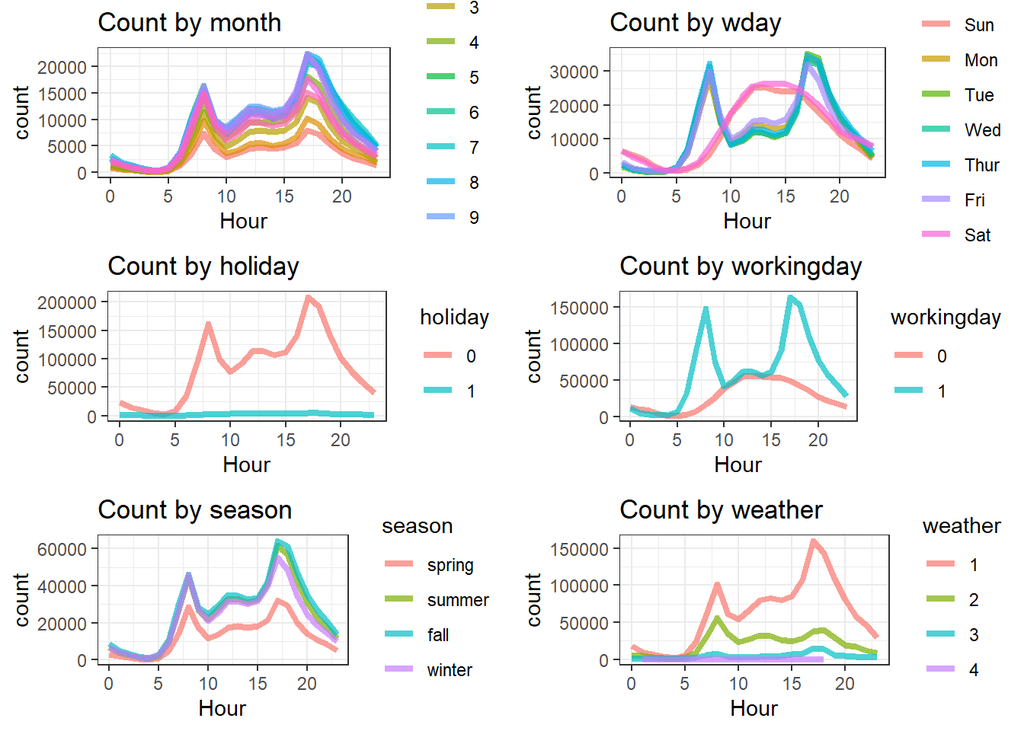

```r
grid.arrange(grobs=lst, ncol=2)
```

```r
bike_res <- all_data %>%
    recipe(count~.) %>%
    step_rm(datetime, year) %>%
    # step_downsample() : category 변수의 level에서 빈도가 가장 낮은 level로 변환
    # step_boxCox(all_numeric()) : boxcox transformation : 분포의 정규성 맞춰줌
    # step_smote() : category level 빈도가 불균형일 때
    step_log(count, offset = 1) %>%
    step_dummy(all_nominal()) %>%
    step_nzv(all_numeric()) %>%
    #step_YeoJohnson(all_numeric(), -all_outcomes()) %>% : boxcox와 비슷
    #step_normalize(all_numeric(), -all_outcomes()) %>%
    prep(training = all_data)
```

```r
all_data2 <- juice(bike_res)
train_index <- seq_len(nrow(train))
train2 <- all_data2[train_index,]
test2 <- all_data2[-train_index,]
```

# XGboost

```r
xgb_spec <- boost_tree(
    trees = 1000, # 앙상블에 포함되는 tree의 수
    tree_depth = tune(), # 얼만큼 노드를 split할건지
    min_n = tune(), # 노드를 분할하는데 필요한 최소 데이터의 수
    loss_reduction = tune(), # 노드 분할에 필요한 loss의 감소량
    sample_size = tune(), # The amount of data exposed to the fitting routine
    mtry = tune(), # The number of predictors that will be randomly sampled at each split when creating the tree models.
    learn_rate = tune()
) %>%
    set_engine('xgboost', objective = "reg:squarederror") %>%
    set_mode('regression')
```

```r
xgb_grid <- grid_latin_hypercube(
    tree_depth(),
    min_n(),
    loss_reduction(),
    sample_size = sample_prop(),
    finalize(mtry(), train2), # mtry() : [1, ?], finalize(mtry(), train2) : [1, 30]
    learn_rate(),
    size = 30
)
```

```r
xgb_wf <- workflow() %>%
    add_formula(count~.) %>%
    add_model(xgb_spec)
```

```r
set.seed(1234)
vb_folds <- vfold_cv(train2, v = 5, strata = count)
vb_folds
```

```
## #  5-fold cross-validation using stratification
## # A tibble: 5 x 2
##   splits              id
##   <list>              <chr>
## 1 <split [8707/2179]> Fold1
## 2 <split [8707/2179]> Fold2
## 3 <split [8710/2176]> Fold3
## 4 <split [8710/2176]> Fold4
## 5 <split [8710/2176]> Fold5
```

```r
library(tictoc)
tic()
doParallel::registerDoParallel()
set.seed(1234)

xgb_res <- tune_grid(
    xgb_wf, # recipe, formula를 지정해준 workflow
    resamples = vb_folds,
    grid = xgb_grid, # grid_latin_hypercube
    control = control_grid(save_pred = TRUE) # out of sample predicton 값 저장. test data에 fitting 한 뒤에 collect_prediction()으로 예측값을 확인할 때 사용됨. classification 문제에서는 roc curve를 그리는데에도 활용됨
)
toc() # 540.33 sec
```

```
## 702.86 sec elapsed
```

```r
show_best(xgb_res, 'rmse')
```

```
## # A tibble: 5 x 12
##    mtry min_n tree_depth learn_rate loss_reduction sample_size .metric
##   <int> <int>      <int>      <dbl>          <dbl>       <dbl> <chr>
## 1    25     3         12    0.0470        1.39e- 6       0.576 rmse
## 2    17    25         13    0.0812        4.79e-10       0.358 rmse
## 3    15     6          4    0.0182        1.52e- 5       0.769 rmse
## 4    19    22          8    0.00372       5.32e- 1       0.255 rmse
## 5    12    31         15    0.00925       2.25e+ 1       0.224 rmse
## # ... with 5 more variables: .estimator <chr>, mean <dbl>, n <int>,
## #   std_err <dbl>, .config <chr>
```

```r
best_param <- select_best(xgb_res, 'rmse')

final_xgb <- finalize_workflow(xgb_wf, best_param)
final_xgb
```

```
## == Workflow ====================================================================
## Preprocessor: Formula
## Model: boost_tree()
##
## -- Preprocessor ----------------------------------------------------------------
## count ~ .
##
## -- Model -----------------------------------------------------------------------
## Boosted Tree Model Specification (regression)
##
## Main Arguments:
##   mtry = 25
##   trees = 1000
##   min_n = 3
##   tree_depth = 12
##   learn_rate = 0.0470497456522646
##   loss_reduction = 1.39072338782054e-06
##   sample_size = 0.576114785603713
##
## Engine-Specific Arguments:
##   objective = reg:squarederror
##
## Computational engine: xgboost
```

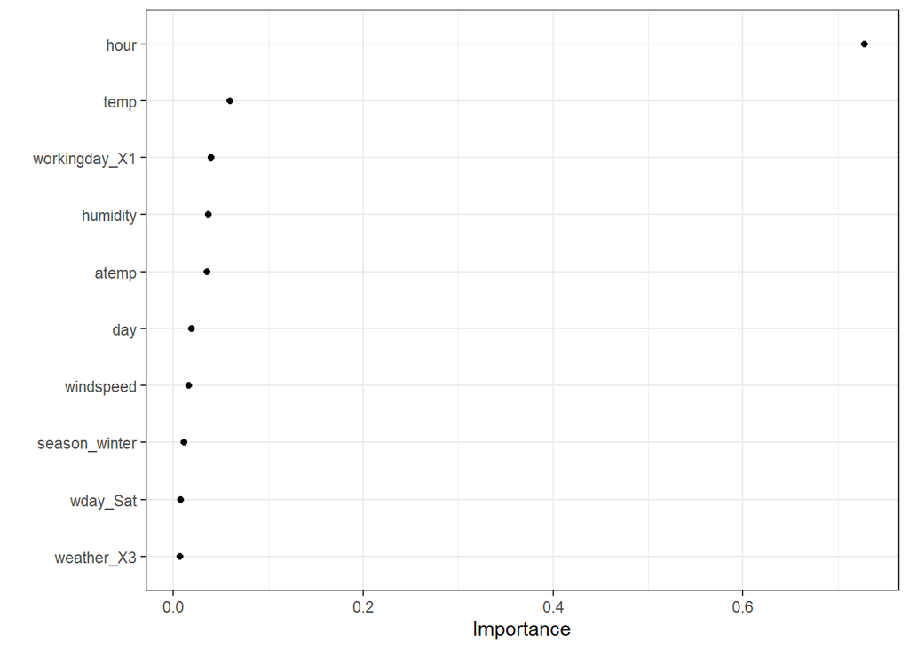

```r
library(vip) # feature importance plot 그리기
final_xgb %>%
    fit(data = train2) %>%  # iter, training_rmse
    pull_workflow_fit() %>% #  http://www.rebeccabarter.com/blog/2020-03-25_machine_learning/
    vip(geom = 'point')
```

```r
final_model <- finalize_model(xgb_spec, best_param)
final_model # tuning이 끝난 최종 모형
```

```
## Boosted Tree Model Specification (regression)
##
## Main Arguments:
##   mtry = 25
##   trees = 1000
##   min_n = 3
##   tree_depth = 12
##   learn_rate = 0.0470497456522646
##   loss_reduction = 1.39072338782054e-06
##   sample_size = 0.576114785603713
##
## Engine-Specific Arguments:
##   objective = reg:squarederror
##
## Computational engine: xgboost
```

```r
final_workflow <- xgb_wf %>% update_model(final_model)
xgb_fit <- fit(final_workflow, data = train2)


pred_xgb <-
    predict(xgb_fit, test2) %>%
    mutate(modelo = "XGBoost")

pred_xgb %>% filter(.pred < 0)
```

```
## # A tibble: 0 x 2
## # ... with 2 variables: .pred <dbl>, modelo <chr>
```

# LASSO

```r
lasso_spec <- linear_reg(penalty = tune(), mixture = 1) %>% # mixture = 1 : LASSO, 0 : ridge
  set_engine("glmnet")

lasso_wf <- workflow() %>%
    add_formula(count~.) %>%
    add_model(lasso_spec)

lambda_grid <- grid_regular(penalty(), levels = 50) # https://cran.r-project.org/web/packages/dials/vignettes/Basics.html

tic()
doParallel::registerDoParallel()
lasso_res <- tune_grid(
    lasso_wf,
    resamples = vb_folds,
    grid = lambda_grid,
    control = control_grid(save_pred = TRUE),
)
toc() # 12.14 sec
```

```
## 12.83 sec elapsed
```

```r
lasso_res %>%
    collect_metrics()
```

```
## # A tibble: 100 x 7
##     penalty .metric .estimator  mean     n std_err .config
##       <dbl> <chr>   <chr>      <dbl> <int>   <dbl> <chr>
##  1 1.00e-10 rmse    standard   1.02      5 0.00567 Preprocessor1_Model01
##  2 1.00e-10 rsq     standard   0.481     5 0.00654 Preprocessor1_Model01
##  3 1.60e-10 rmse    standard   1.02      5 0.00567 Preprocessor1_Model02
##  4 1.60e-10 rsq     standard   0.481     5 0.00654 Preprocessor1_Model02
##  5 2.56e-10 rmse    standard   1.02      5 0.00567 Preprocessor1_Model03
##  6 2.56e-10 rsq     standard   0.481     5 0.00654 Preprocessor1_Model03
##  7 4.09e-10 rmse    standard   1.02      5 0.00567 Preprocessor1_Model04
##  8 4.09e-10 rsq     standard   0.481     5 0.00654 Preprocessor1_Model04
##  9 6.55e-10 rmse    standard   1.02      5 0.00567 Preprocessor1_Model05
## 10 6.55e-10 rsq     standard   0.481     5 0.00654 Preprocessor1_Model05
## # ... with 90 more rows
```

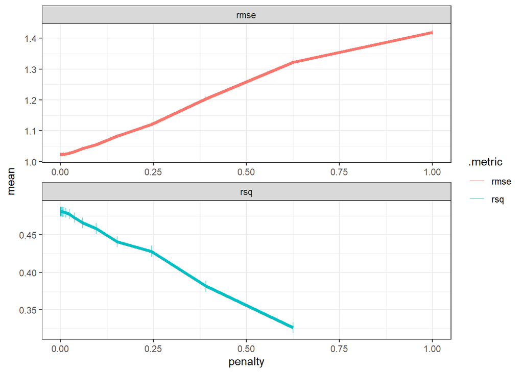

```r
lasso_res %>%
    collect_metrics() %>%
    ggplot(aes(penalty, mean, color = .metric)) + # .metric : rmse
    geom_errorbar(aes(ymin = mean - std_err, ymax = mean + std_err), alpha = 0.5) +
    geom_line(size = 1.5, show.legend = F) +
    facet_wrap(~.metric, scales = 'free', nrow = 2)
```

```r
show_best(lasso_res, 'rmse')
```

```
## # A tibble: 5 x 7
##    penalty .metric .estimator  mean     n std_err .config
##      <dbl> <chr>   <chr>      <dbl> <int>   <dbl> <chr>
## 1 8.69e- 4 rmse    standard    1.02     5 0.00567 Preprocessor1_Model35
## 2 1.00e-10 rmse    standard    1.02     5 0.00567 Preprocessor1_Model01
## 3 1.60e-10 rmse    standard    1.02     5 0.00567 Preprocessor1_Model02
## 4 2.56e-10 rmse    standard    1.02     5 0.00567 Preprocessor1_Model03
## 5 4.09e-10 rmse    standard    1.02     5 0.00567 Preprocessor1_Model04
```

```r
best_param_lasso <- select_best(lasso_res, 'rmse')
final_model <- finalize_model(lasso_spec, best_param_lasso)
final_workflow <- lasso_wf %>% update_model(final_model)
lasso_fit <- fit(final_workflow, data = train2)

pred_lasso <-
    predict(lasso_fit, test2) %>%
    mutate(modelo = "LASSO")

pred_lasso
```

```
## # A tibble: 6,493 x 2
##    .pred modelo
##    <dbl> <chr>
##  1  2.78 LASSO
##  2  2.85 LASSO
##  3  2.94 LASSO
##  4  3.05 LASSO
##  5  3.15 LASSO
##  6  3.12 LASSO
##  7  3.16 LASSO
##  8  3.33 LASSO
##  9  3.43 LASSO
## 10  3.76 LASSO
## # ... with 6,483 more rows
```

# random forest

#rf_wf <- workflow() %>% # add_formula(count~.) %>% # add_model(rf_spec)

#tic() #doParallel::registerDoParallel()

#set.seed(1234) #rf_folds <- bootstraps(train2, strata = count)

#rf_res <- tune_grid( # rf_wf, # resamples = rf_folds, # grid = 11, # control = control_grid(save_pred = TRUE), #) #toc()

#show_best(rf_res, ‘rmse’) #best_param_rf <- select_best(rf_res, ‘rmse’) #final_model_rf <- finalize_model(rf_spec, best_param_rf) #final_workflow_rf <- rf_wf %>% update_model(final_model_rf) #rf_fit <- fit(final_workflow_rf, data = train2)

#pred_rf <- # predict(rf_fit, test2) %>% # mutate(modelo = “RF”)

```r
#subfile <- read_csv("C:/Users/uos/Desktop/kaggle-study/data/bike #sharing/sampleSubmission.csv")
#subfile

#subfile$count <- exp(pred_lasso$.pred)

#write.csv(subfile, row.names = FALSE,
#          "C:/Users/uos/Desktop/kaggle-study/data/bike #sharing/bh_xgb.csv")

#write.csv(subfile, row.names = FALSE,
#          "C:/Users/uos/Desktop/kaggle-study/data/bike #sharing/bh_lasso.csv")

# xgb : 0.50121
# LASSO : 1.04176
```

# bayes tune

```r
#
# params <- parameters(xgb_spec) %>%
#     finalize(train2)
#
# xgboost_wflow <- workflow() %>%
#     add_recipe(bike_res) %>%
#     add_model(xgb_spec)
#
#
# library(parallel)
# options(tidymodels.dark = TRUE)
# cl <- makePSOCKcluster(6)
# set.seed(1234)
# folds <- vfold_cv(train2, v = 5, strata = 'count')
#
# tuned <- tune_bayes(
#     object = xgboost_wflow,
#     resamples = folds,
#     param_info = params,
#     iter = 30,
#     metrics =  metric_set(rmse, mape),
#     initial = 10,
#     control = control_bayes(
#         verbose = TRUE,
#         no_improve = 10,
#         seed = 123
#      )
#  )
#
```